# R Notebook

Logic Regression Homework

Predictive classifier. Customer buy CH or MN. train-test splitting or Cross-validation. - manual or glmulti() - mutate purchase to purchase_mm - mutate factor - weekofpurchase? - aliases? - Highest AUC

categorical? store7,special_ ,purchase

```r
library(tidyverse)
library(janitor)
library(GGally)
library(modelr)
```

```r
orange_juice <- read_csv('data/orange_juice.csv') %>% clean_names()
glimpse(orange_juice)
```

```
Rows: 1,070
Columns: 18
$ purchase        <chr> "CH", "CH", "CH", "MM", "CH", "CH", "CH", "CH", "CH", "CH", "CH", "CH", "CH", "CH", "CH", "CH", "MM", "MM", "MM", "CH", "CH", "CH", "CH",…
$ weekof_purchase <dbl> 237, 239, 245, 227, 228, 230, 232, 234, 235, 238, 240, 263, 276, 268, 278, 278, 240, 268, 269, 254, 257, 258, 259, 264, 268, 269, 271, 27…
$ store_id        <dbl> 1, 1, 1, 1, 7, 7, 7, 7, 7, 7, 7, 7, 7, 7, 7, 7, 1, 2, 2, 7, 7, 1, 7, 7, 7, 7, 7, 7, 7, 7, 2, 7, 2, 2, 3, 3, 1, 1, 4, 4, 4, 4, 4, 4, 4, 4,…
$ price_ch        <dbl> 1.75, 1.75, 1.86, 1.69, 1.69, 1.69, 1.69, 1.75, 1.75, 1.75, 1.86, 1.86, 1.99, 1.86, 2.06, 2.06, 1.75, 1.86, 1.86, 1.86, 1.86, 1.76, 1.86,…
$ price_mm        <dbl> 1.99, 1.99, 2.09, 1.69, 1.69, 1.99, 1.99, 1.99, 1.99, 1.99, 2.09, 2.13, 2.13, 2.13, 2.13, 2.13, 1.99, 2.18, 2.18, 2.18, 2.18, 2.18, 2.18,…
$ disc_ch         <dbl> 0.00, 0.00, 0.17, 0.00, 0.00, 0.00, 0.00, 0.00, 0.00, 0.00, 0.00, 0.27, 0.00, 0.00, 0.00, 0.00, 0.00, 0.00, 0.00, 0.00, 0.00, 0.00, 0.00,…
$ disc_mm         <dbl> 0.00, 0.30, 0.00, 0.00, 0.00, 0.00, 0.40, 0.40, 0.40, 0.40, 0.00, 0.00, 0.54, 0.00, 0.00, 0.00, 0.30, 0.00, 0.00, 0.00, 0.00, 0.00, 0.00,…
$ special_ch      <dbl> 0, 0, 0, 0, 0, 0, 1, 1, 0, 0, 0, 0, 0, 0, 0, 0, 0, 0, 0, 0, 0, 0, 0, 1, 0, 1, 0, 0, 1, 0, 0, 1, 0, 1, 0, 0, 0, 0, 1, 0, 0, 0, 0, 0, 0, 0,…
$ special_mm      <dbl> 0, 1, 0, 0, 0, 1, 1, 0, 0, 0, 0, 0, 1, 0, 0, 0, 1, 1, 0, 0, 0, 0, 0, 0, 0, 0, 0, 0, 0, 0, 0, 0, 1, 0, 0, 0, 0, 0, 0, 1, 0, 0, 0, 0, 0, 0,…
$ loyal_ch        <dbl> 0.500000, 0.600000, 0.680000, 0.400000, 0.956535, 0.965228, 0.972182, 0.977746, 0.982197, 0.985757, 0.988606, 0.990885, 0.992708, 0.68000…
$ sale_price_mm   <dbl> 1.99, 1.69, 2.09, 1.69, 1.69, 1.99, 1.59, 1.59, 1.59, 1.59, 2.09, 2.13, 1.59, 2.13, 2.13, 2.13, 1.69, 2.18, 2.18, 2.18, 2.18, 2.18, 2.18,…
$ sale_price_ch   <dbl> 1.75, 1.75, 1.69, 1.69, 1.69, 1.69, 1.69, 1.75, 1.75, 1.75, 1.86, 1.59, 1.99, 1.86, 2.06, 2.06, 1.75, 1.86, 1.86, 1.86, 1.86, 1.76, 1.86,…
$ price_diff      <dbl> 0.24, -0.06, 0.40, 0.00, 0.00, 0.30, -0.10, -0.16, -0.16, -0.16, 0.23, 0.54, -0.40, 0.27, 0.07, 0.07, -0.06, 0.32, 0.32, 0.32, 0.32, 0.42…
$ store7          <chr> "No", "No", "No", "No", "Yes", "Yes", "Yes", "Yes", "Yes", "Yes", "Yes", "Yes", "Yes", "Yes", "Yes", "Yes", "No", "No", "No", "Yes", "Yes…
$ pct_disc_mm     <dbl> 0.000000, 0.150754, 0.000000, 0.000000, 0.000000, 0.000000, 0.201005, 0.201005, 0.201005, 0.201005, 0.000000, 0.000000, 0.253521, 0.00000…
$ pct_disc_ch     <dbl> 0.000000, 0.000000, 0.091398, 0.000000, 0.000000, 0.000000, 0.000000, 0.000000, 0.000000, 0.000000, 0.000000, 0.145161, 0.000000, 0.00000…
$ list_price_diff <dbl> 0.24, 0.24, 0.23, 0.00, 0.00, 0.30, 0.30, 0.24, 0.24, 0.24, 0.23, 0.27, 0.14, 0.27, 0.07, 0.07, 0.24, 0.32, 0.32, 0.32, 0.32, 0.42, 0.32,…
$ store           <dbl> 1, 1, 1, 1, 0, 0, 0, 0, 0, 0, 0, 0, 0, 0, 0, 0, 1, 2, 2, 0, 0, 1, 0, 0, 0, 0, 0, 0, 0, 0, 2, 0, 2, 2, 3, 3, 1, 1, 4, 4, 4, 4, 4, 4, 4, 4,…
```

```r
#Check for NAs
summary(orange_juice)
```

```
   purchase         weekof_purchase    store_id       price_ch        price_mm        disc_ch           disc_mm         special_ch       special_mm
 Length:1070        Min.   :227.0   Min.   :1.00   Min.   :1.690   Min.   :1.690   Min.   :0.00000   Min.   :0.0000   Min.   :0.0000   Min.   :0.0000
 Class :character   1st Qu.:240.0   1st Qu.:2.00   1st Qu.:1.790   1st Qu.:1.990   1st Qu.:0.00000   1st Qu.:0.0000   1st Qu.:0.0000   1st Qu.:0.0000
 Mode  :character   Median :257.0   Median :3.00   Median :1.860   Median :2.090   Median :0.00000   Median :0.0000   Median :0.0000   Median :0.0000
                    Mean   :254.4   Mean   :3.96   Mean   :1.867   Mean   :2.085   Mean   :0.05186   Mean   :0.1234   Mean   :0.1477   Mean   :0.1617
                    3rd Qu.:268.0   3rd Qu.:7.00   3rd Qu.:1.990   3rd Qu.:2.180   3rd Qu.:0.00000   3rd Qu.:0.2300   3rd Qu.:0.0000   3rd Qu.:0.0000
                    Max.   :278.0   Max.   :7.00   Max.   :2.090   Max.   :2.290   Max.   :0.50000   Max.   :0.8000   Max.   :1.0000   Max.   :1.0000
    loyal_ch        sale_price_mm   sale_price_ch     price_diff         store7           pct_disc_mm      pct_disc_ch      list_price_diff     store
 Min.   :0.000011   Min.   :1.190   Min.   :1.390   Min.   :-0.6700   Length:1070        Min.   :0.0000   Min.   :0.00000   Min.   :0.000   Min.   :0.000
 1st Qu.:0.325257   1st Qu.:1.690   1st Qu.:1.750   1st Qu.: 0.0000   Class :character   1st Qu.:0.0000   1st Qu.:0.00000   1st Qu.:0.140   1st Qu.:0.000
 Median :0.600000   Median :2.090   Median :1.860   Median : 0.2300   Mode  :character   Median :0.0000   Median :0.00000   Median :0.240   Median :2.000
 Mean   :0.565782   Mean   :1.962   Mean   :1.816   Mean   : 0.1465                      Mean   :0.0593   Mean   :0.02731   Mean   :0.218   Mean   :1.631
 3rd Qu.:0.850873   3rd Qu.:2.130   3rd Qu.:1.890   3rd Qu.: 0.3200                      3rd Qu.:0.1127   3rd Qu.:0.00000   3rd Qu.:0.300   3rd Qu.:3.000
 Max.   :0.999947   Max.   :2.290   Max.   :2.090   Max.   : 0.6400                      Max.   :0.4020   Max.   :0.25269   Max.   :0.440   Max.   :4.000
```

```r
orange_juice <- orange_juice %>%
  select(-c(2,3,14,18))
```

Mutate

```r
orange_juice <- orange_juice %>%
  mutate_if(is_character, as_factor) %>%
  mutate(purchase_mm = as_factor(if_else(purchase == 'CH', "Yes", "No")))
```

Which juice = Dependent variable: purchase_mm

aliases/ dependencies?

```r
alias(purchase_mm ~ ., data = orange_juice)
```

```
Model :
purchase_mm ~ purchase + price_ch + price_mm + disc_ch + disc_mm +
    special_ch + special_mm + loyal_ch + sale_price_mm + sale_price_ch +
    price_diff + pct_disc_mm + pct_disc_ch + list_price_diff

Complete :
                (Intercept) purchaseMM price_ch price_mm disc_ch disc_mm special_ch special_mm loyal_ch pct_disc_mm pct_disc_ch
sale_price_mm    0           0          0        1        0      -1       0          0          0        0           0
sale_price_ch    0           0          1        0       -1       0       0          0          0        0           0
price_diff       0           0         -1        1        1      -1       0          0          0        0           0
list_price_diff  0           0         -1        1        0       0       0          0          0        0           0
```

Result. aliases = sale_price_mm,sale_price_ch,price_diff,list_price_diff

[output not shown]

[output cut: 990 more lines]

Relations with purchase_mm. There are 10 variables too much for ggpairs. Divided in 2 groups of 5

```r
div1 <- orange_juice %>%
  select(price_ch,price_mm,price_diff,disc_ch,disc_mm,purchase_mm)
```

[output not shown]

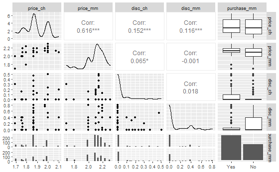

I interpret a relation between purchase_mm and disc_mm

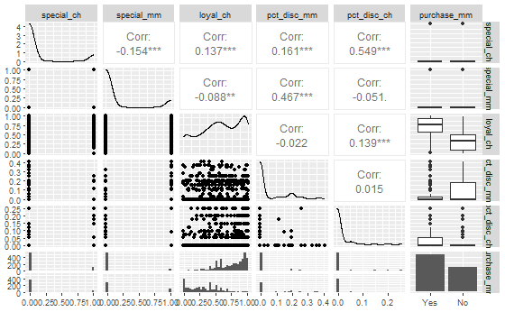

I interpret a relation between purchase_mm and loyal_ch

Logistic Regression predictions according which I interpreted from each model. With one predictor

```r
model1_pred
```

```
Call:  glm(formula = purchase_mm ~ disc_mm, family = binomial(link = "logit"),
    data = orange_juice)

Coefficients:
(Intercept)      disc_mm
    -0.6504       1.5736

Degrees of Freedom: 1069 Total (i.e. Null);  1068 Residual
Null Deviance:      1431
Residual Deviance: 1402     AIC: 1406
```

```r
model2_pred
```

```
Call:  glm(formula = purchase_mm ~ loyal_ch, family = binomial(link = "logit"),
    data = orange_juice)

Coefficients:
(Intercept)     loyal_ch
      2.755       -6.095

Degrees of Freedom: 1069 Total (i.e. Null);  1068 Residual
Null Deviance:      1431
Residual Deviance: 920.6    AIC: 924.6
```

An extra model prediction with all variables/ predictors

```r
model3_pred
```

```
Call:  glm(formula = purchase_mm ~ ., family = binomial(link = "logit"),
    data = orange_juice)

Coefficients:
(Intercept)   purchaseMM     price_ch     price_mm      disc_ch      disc_mm   special_ch   special_mm     loyal_ch  pct_disc_mm  pct_disc_ch
 -2.657e+01    5.313e+01   -1.059e-10   -2.922e-10   -1.351e-09    2.974e-09   -1.047e-11    3.493e-11    4.676e-11   -6.223e-09    2.557e-09

Degrees of Freedom: 1069 Total (i.e. Null);  1059 Residual
Null Deviance:      1431
Residual Deviance: 6.208e-09    AIC: 22
```

From these models predictions the lowest AIC ( and best) is with all the variables.

However I will plot the first model

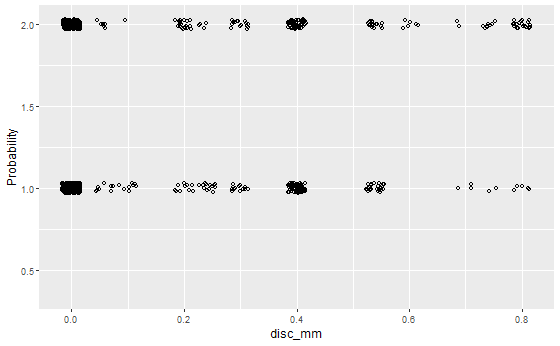

No enough data for do a logic regression. I understand that my first model from previous interpretation is incorrect or invalid.

```r
library(broom)
```

model1 - one predictor

| estimate |
| --- |
| 1.573648 |

| term | estimate | std_error | statistic | p_value |
| --- | --- | --- | --- | --- |
| (Intercept) | -0.6503846 | 0.0742145 | -8.763578 | 1.891489e-18 |
| disc_mm | 1.5736477 | 0.2941492 | 5.349828 | 8.803802e-08 |

model2 - one predictor

| term | estimate | std_error | statistic | p_value |
| --- | --- | --- | --- | --- |
| (Intercept) | 2.755397 | 0.1995901 | 13.80528 | 2.368569e-43 |
| loyal_ch | -6.094763 | 0.3611485 | -16.87606 | 6.750426e-64 |

model3 - all predictor

| term | estimate | std_error | statistic | p_value |
| --- | --- | --- | --- | --- |
| (Intercept) | -2.656607e+01 | 250502.57 | -1.060511e-04 | 0.9999154 |
| purchaseMM | 5.313214e+01 | 30442.74 | 1.745314e-03 | 0.9986074 |
| price_ch | -1.058536e-10 | 156036.97 | -6.783880e-16 | 1.0000000 |
| price_mm | -2.922362e-10 | 110981.22 | -2.633204e-15 | 1.0000000 |
| disc_ch | -1.351262e-09 | 2462583.78 | -5.487172e-16 | 1.0000000 |
| disc_mm | 2.974254e-09 | 1167115.44 | 2.548380e-15 | 1.0000000 |
| special_ch | -1.046502e-11 | 42384.08 | -2.469093e-16 | 1.0000000 |
| special_mm | 3.493260e-11 | 35347.24 | 9.882695e-16 | 1.0000000 |
| loyal_ch | 4.676484e-11 | 46710.21 | 1.001169e-15 | 1.0000000 |
| pct_disc_mm | -6.222946e-09 | 2451908.28 | -2.538001e-15 | 1.0000000 |

[output cut: 1 more lines]

| null_deviance | df_null | log_lik | aic | bic | deviance | df_residual | nobs |
| --- | --- | --- | --- | --- | --- | --- | --- |
| 1430.852 | 1069 | -700.7935 | 1405.587 | 1415.538 | 1401.587 | 1068 | 1070 |

| null_deviance | df_null | log_lik | aic | bic | deviance | df_residual | nobs |
| --- | --- | --- | --- | --- | --- | --- | --- |
| 1430.852 | 1069 | -460.285 | 924.5701 | 934.5209 | 920.5701 | 1068 | 1070 |

| null_deviance | df_null | log_lik | aic | bic | deviance | df_residual | nobs |
| --- | --- | --- | --- | --- | --- | --- | --- |
| 1430.852 | 1069 | -3.103741e-09 | 22 | 76.72955 | 6.207692e-09 | 1059 | 1070 |

ROC/AUC

```r
library(pROC)
```

```r
orange_juice_mod2 <- orange_juice %>%
  add_predictions((model2_pred, type = 'response'))
```

[output not shown]

```r
roc_orange_juice_mod1 <- orange_juice_mod1 %>%
  roc(response = purchase_mm, predictor = pred)
```

```r
roc_orange_juice_mod2 <- orange_juice_mod2 %>%
  roc(response = purchase_mm, predictor = pred)
```

```r
roc_orange_juice_mod3 <- orange_juice_mod3 %>%
  roc(response = purchase_mm, predictor = pred)
```

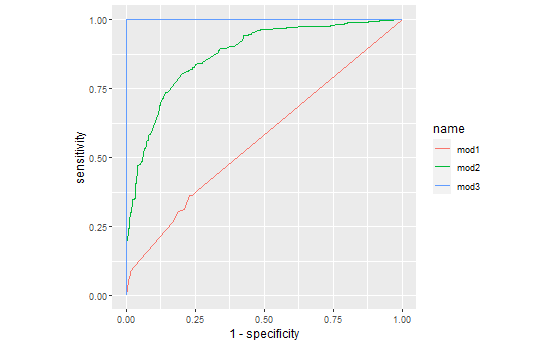

The ROC plot shows that the best model is model 3, doing with all the variables/ predictors after cleaning/ eliminate some variables. But is not a curve, it is completely straight so I feel it should not be a better model. The second best model , that shows a curve is model2 (with loyal_ch), maybe the most realistic. The worst prediction is model1 (disc_mm) that is close to a straight line.

AUC values

```r
auc(roc_orange_juice_mod1)
```

```
Area under the curve: 0.5702
```

```r
auc(roc_orange_juice_mod2)
```

```
Area under the curve: 0.874
```

```r
auc(roc_orange_juice_mod3)
```

```
Area under the curve: 1
```

Cross-validation

```r
  model1_pred_cross_val<- train(model1_pred$formula,
                                dat = orange_juice,trControl = train_control,
                                method = 'glm',
                                family = binomial(link =  'logit'))
```

```r
  model2_pred_cross_val<- train(model2_pred$formula,
                                dat = orange_juice,trControl = train_control,
                                method = 'glm',
                                family = binomial(link =  'logit'))
```

```r
  model3_pred_cross_val<- train(model3_pred$formula,
                                dat = orange_juice,trControl = train_control,
                                method = 'glm',
                                family = binomial(link =  'logit'))
```

|  | parameter | ROC | Sens | Spec | ROCSD | SensSD | SpecSD |
| --- | --- | --- | --- | --- | --- | --- | --- |
| 1 | none | 0.5701594 | 0.9153628 | 0.1605429 | 0.03925168 | 0.07228073 | 0.056789 |

|  | parameter | ROC | Sens | Spec | ROCSD | SensSD | SpecSD |
| --- | --- | --- | --- | --- | --- | --- | --- |
| 1 | none | 0.8739048 | 0.8717355 | 0.7059547 | 0.02839915 | 0.03576761 | 0.0608506 |

|  | parameter | ROC | Sens | Spec | ROCSD | SensSD | SpecSD |
| --- | --- | --- | --- | --- | --- | --- | --- |
| 1 | none | 1 | 1 | 1 | 0 | 0 | 0 |

Answer. The highest AUC/ROC is 1 that is the model with alll the variables/ predictor except that ones remove during data -cleaning and after apply aliases. the second best model / predictor is model2 with ‘loyal_ch’.